# Influence diagnostics in a linear regression model

Blog post

Author

Steve Simon

Published

October 2, 2025

There are four important assumptions in linear regression: normality, homogeneity, linearity, independence. You assess these assumptions with various plots of the residuals. In addition to checking those assumptions, you should also assess various influence diagnostics. Influence diagnostics measure how much your linear regression model is dependent on any one data point.

If you find out that one point out of many influences your model, that is not a violation of assumptions. Rather, it becomes the focus of further investigation.

## The artificial dataset

```
# A tibble: 6 × 2
      x     y
  <dbl> <dbl>
1     4    34
2     6    20
3     8    10
4    10    32
5    12     6
6    14    24
```

Most of the time, I try to avoid using artificial datasets. I am making an exception here because I want to show the internal calculations using numbers that are easy to work with.

There are two variables with generic names, x and y. Treat x as the independent variable and y as the dependent variable. There is nothing unusual about this data. I want to examine how the regression line changes when you remove a data point. It is somewhat reminiscent of the song “You’re Gonna Miss Me When I’m Gone.” This a song Anna Kendrick was sung by Anna Kendrick in Pitch Perfect that include some clever percussion with an empty cup. The original song actually goes all the way back to 1931. In any case, most data points in a linear regression aren’t missed if they are removed. But in a few cases, a point can be missed when the regression line jumps after that point is removed.

## Scatterplot of the hypothetical data

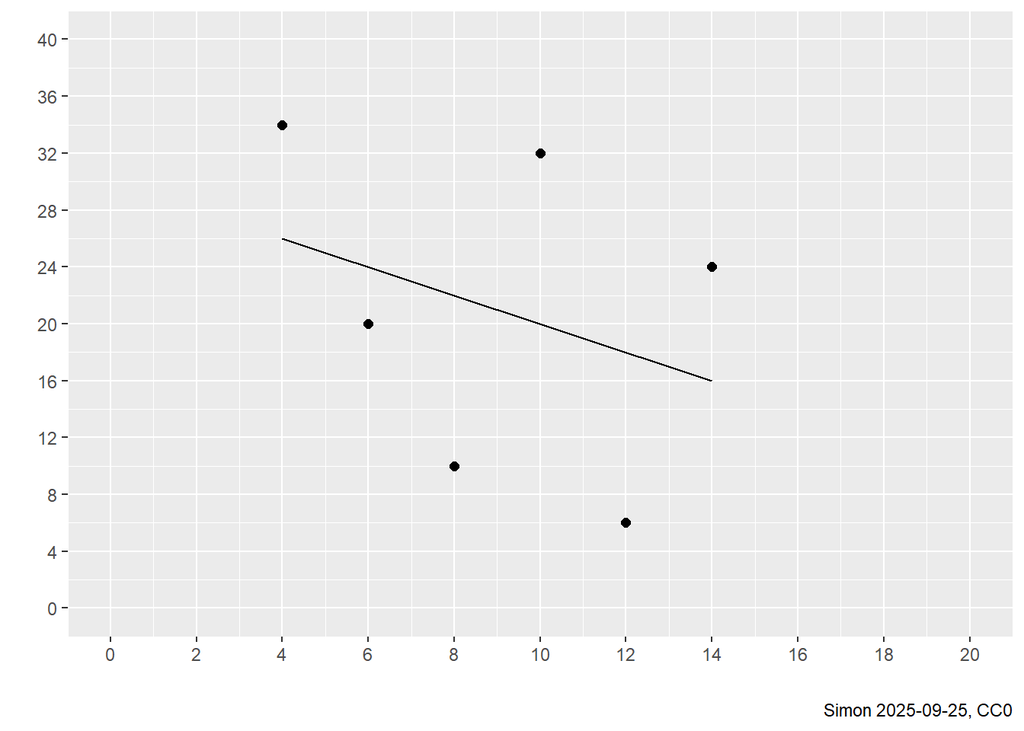

Here is a plot of the data with the least squares line. There is a weak negative trend.

## Deleting the first point

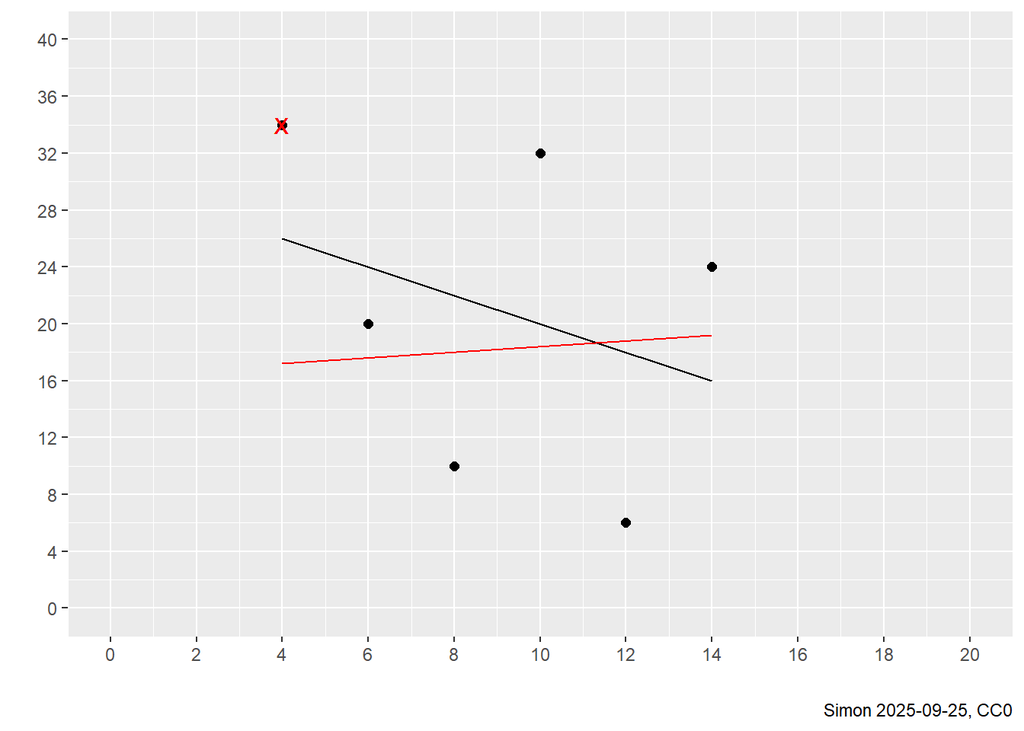

There is a big change in the predictions when the first data point is removed. A data point is characterized as influential if it is missed when it is gone

## Deleting the second point

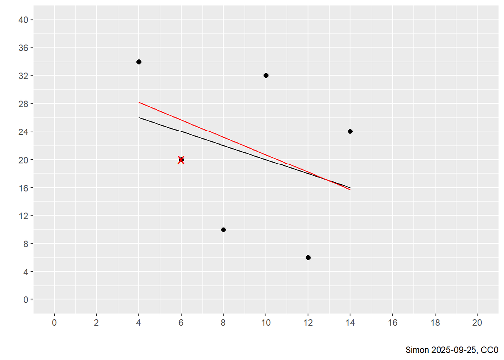

Ther regression line changes much less after the second data point is removed. This is also true for the third and fourth data points are removed.

## Deleting the third point

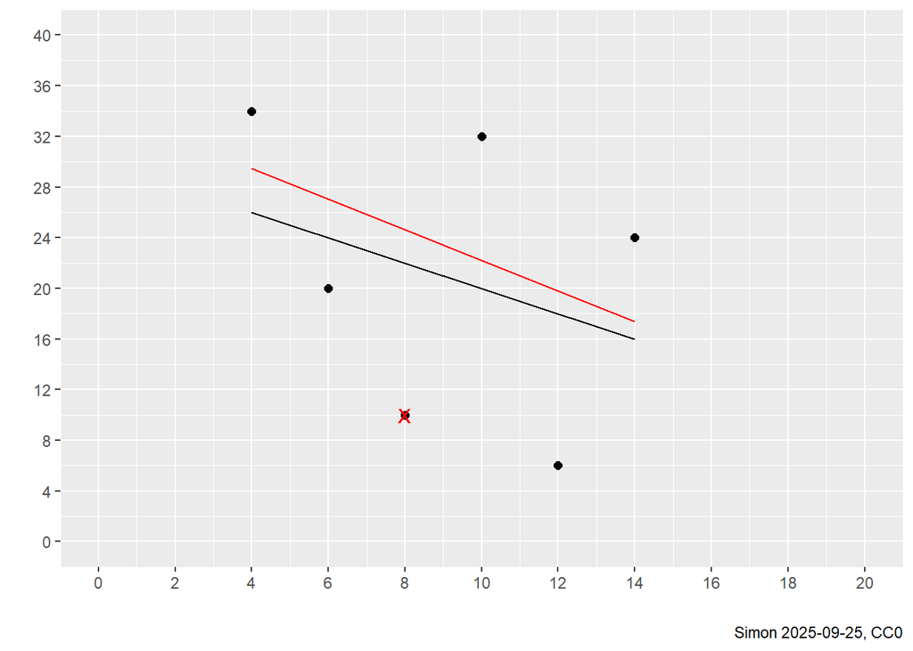

## Deleting the fourth point

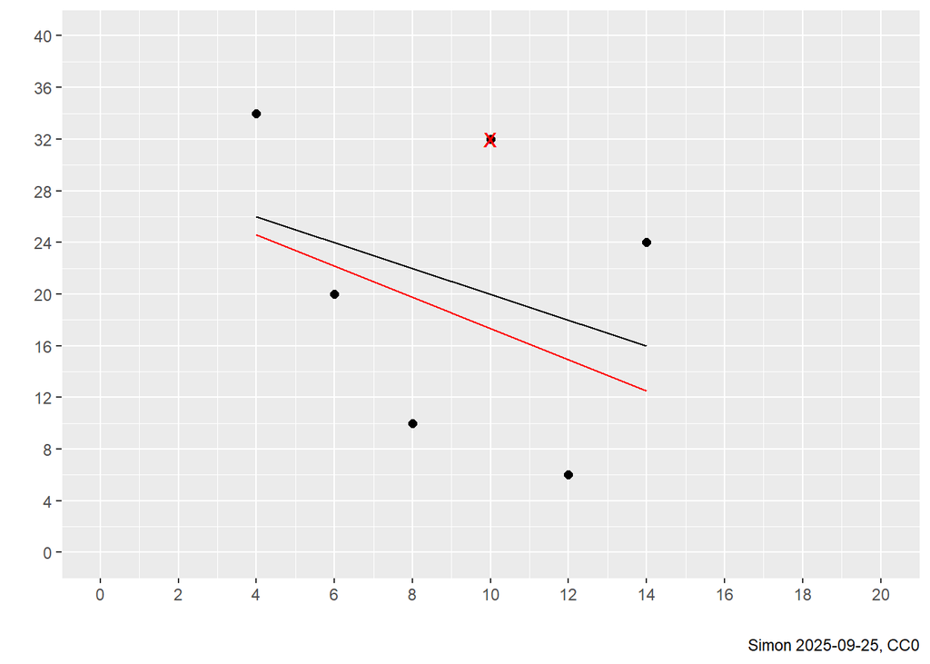

## Deleting the fifth point

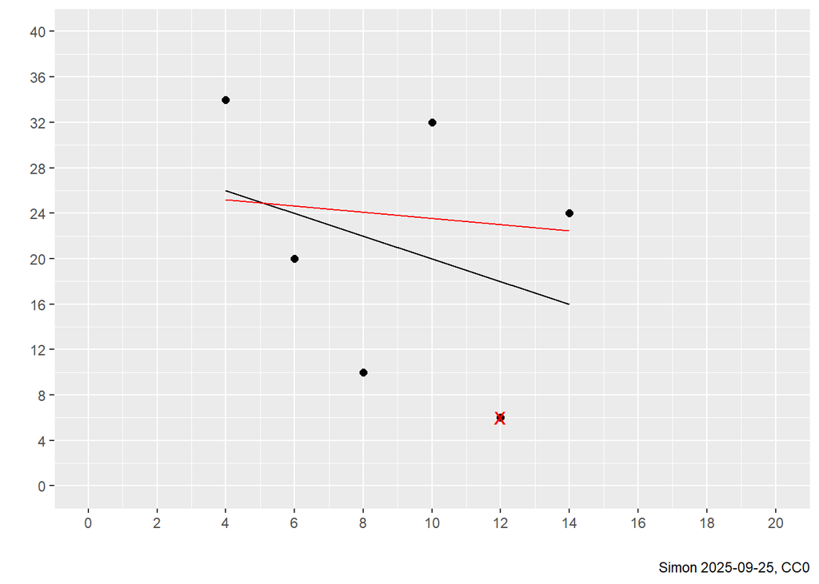

Like the first data point, the fifth data point is influential because of the large jump in the regression line.

## Deleting the sixth point

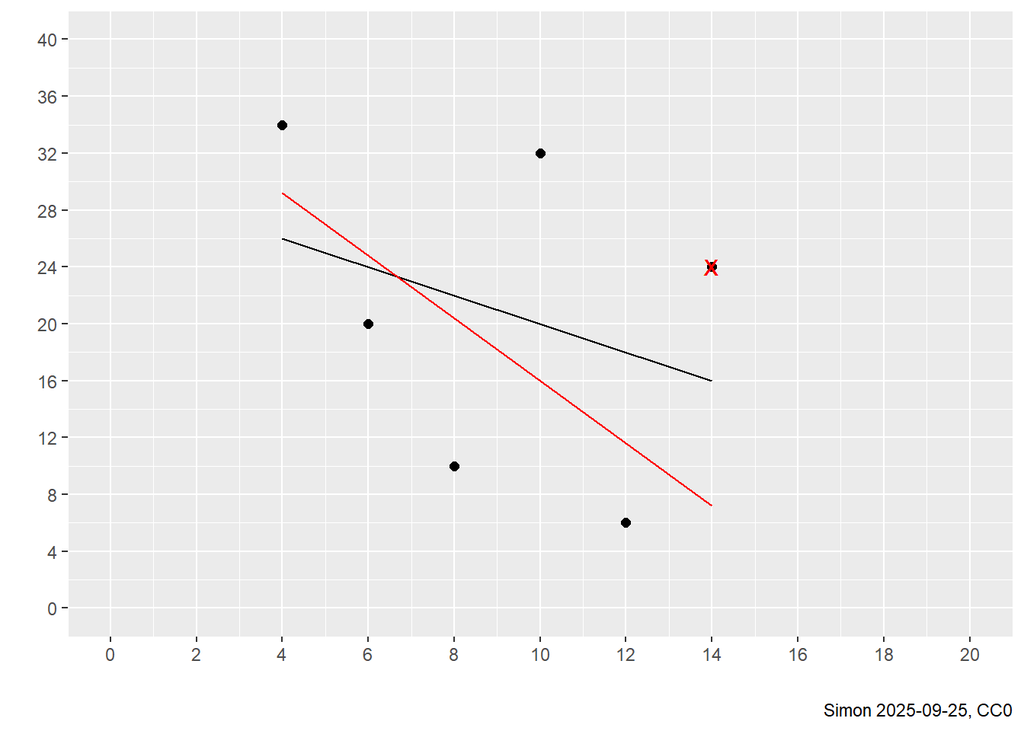

The sixth data point is also influential.

## What makes a point influential?

There are two factors that make a point influential.

First, does it tend to hang around the fringes of the independent variables. With one independent variable, that means, does it tend to be much smaller than the other values of the independent variable or does it tend to be much larger.

With multiple independent variables, it could be on the fringes if it defies the general correlations that you see in the rest of the data. This can happen even if the values of the independent variables do not look too extreme when examined one at a time. So in a study of pre-term births, a gestational age of 36 is not too extreme and a birthweight of 1 kilogram is not too extreme. But 1 kilogram babies almost always have a much earlier gestational age (probably closer to 28 weeks) and 36 week gestational age babies are almost always much heavier than 1 kilogram at birth (probably closer to 2 kilograms). So a 36 week, 1 kilogram baby is at the fringes of the data.

Sidenote: The Hancock Health website has a [nice page](https://www.hancockhealth.org/mayo-health-library/premature-birth/) that shows the norms for various birthweights and gestational ages.

Second, is there a large residual. This is a deviation between what you observed and what your model predicts. You have to standardize this difference because some of the residuals will have much more variation and some will have much less variation. Residuals associated with independent variables at the fringes tend to have much less variation, so even small residuals there could be important.

## Leverage

Leverage is a measure of how much the values of the independent variables for a particular observation are found on the fringes of the data. The term leverage is reminiscent of the famous Archimedes quote “Give me a lever long enough and a fulcrum on which to place it, and I shall move the world.” An observation with high leverage will pull the regression line towards it, possibly to the detriment of the rest of the observations.

Leverage is quantified by looking at the diagonal elements of the hat matrix. The hat matrix is calculated from the matrix of independent variables, and that matrix should include a column of 1’s for the intercept.

If you are familiar with the matrix notation for linear regression, you will recognize the formula for the estimated regression coefficients:

$\hat{\beta}=(X'X)^{-1}X'Y$

The predicted values are computed as

$\hat{Y}=X\hat{\beta}= X(X'X)^{-1}X'Y$

The matrix $X(X'X)^{-1}X'$ is called hat matrix because it converts Y into Y-hat. This is an under-appreciated property of linear regression. The predicted values are just a weighted combination of the Y’s.

Here’s what the hat matrix look like for our small artificial example.

```
      [,1]  [,2] [,3] [,4]  [,5]  [,6]
[1,]  0.52  0.38 0.24 0.10 -0.05 -0.19
[2,]  0.38  0.30 0.21 0.12  0.04 -0.05
[3,]  0.24  0.21 0.18 0.15  0.12  0.10
[4,]  0.10  0.12 0.15 0.18  0.21  0.24
[5,] -0.05  0.04 0.12 0.21  0.30  0.38
[6,] -0.19 -0.05 0.10 0.24  0.38  0.52
```

## Augment

```
# A tibble: 6 × 8
      y     x .fitted .resid  .hat .sigma .cooksd .std.resid
  <dbl> <dbl>   <dbl>  <dbl> <dbl>  <dbl>   <dbl>      <dbl>
1    34     4      26   8.00 0.524   12.1  0.513       0.966
2    20     6      24  -4.00 0.295   13.6  0.0330     -0.397
3    10     8      22 -12    0.181   11.5  0.135      -1.10
4    32    10      20  12    0.181   11.5  0.135       1.10
5     6    12      18 -12    0.295   11.1  0.297      -1.19
6    24    14      16   8.00 0.524   12.1  0.513       0.966
```